# Agreement (Dates)

[Matt Jaquiery](https://github.com/mjaquiery) (matt.jaquiery@psy.ox.ac.uk)

June 2020

[Script run 2020-06-29 10:29:46]

# Introduction

The results from the Dots task have been hard to reconcile with the results of the Dates task. We therefore attempt to replicate some basic results from the Dots task using the Dates task. In this case, we attempt to demonstrate that people prefer to hear advice from an advisor who agrees with them more often, even when both advisors are balanced for objective accuracy in the advice they provide.

# Method

The experimental code is available on [GitHub](https://github.com/oxacclab/ExploringSocialMetacognition), and the experiment can be performed by visiting https://acclab.psy.ox.ac.uk/~mj221/ESM/ACBin/agr.html?PROLIFIC_PID=WriteUp.

# Results

## Exclusions

```
##
##                  ¬FbLowFirst ¬FbHighFirst FbLowFirst FbHighFirst
##   FALSE                   17           18         20          19
##   outlyingTrials           1            1          0           0
```

```
## , ,  = FALSE
##
##
##                highAgreement lowAgreement
##   ¬FbLowFirst              0          237
##   ¬FbHighFirst           252            0
##   FbLowFirst               0            0
##   FbHighFirst              0            0
##
## , ,  = TRUE
##
##
##                highAgreement lowAgreement
##   ¬FbLowFirst              0            0
##   ¬FbHighFirst             0            0
##   FbLowFirst               0          279
##   FbHighFirst            266            0
```

Our final participant list consists of 74 participants who completed an average of 37.96 trials each, of which an average of 23.23 had no feedback.

## Task performance

First we offer a characterisation of the task, to provide the reader with a sense of how the participants performed.

### Decisions

Participants offered estimates of whether various events took place before or after a given year. The correct answers were always between 1900 and 2000. Participants answered by selecting a point on one of two confidence bars, with the choice of bar indicating the chosen answer.

#### Correctness

| decision | mean | CL95.Low | CL95.High |
| --- | --- | --- | --- |
| first | .596 | .572 | .620 |
| last | .658 | .632 | .684 |
| Overall | .627 | .605 | .650 |

| decision | mean | CL95.Low | CL95.High | FeedbackCondition |
| --- | --- | --- | --- | --- |
| first | .603 | .568 | .637 | Feedback |
| last | .652 | .615 | .689 | Feedback |
| Overall | .627 | .596 | .659 | Feedback |
| first | .589 | .554 | .625 | No Feedback |
| last | .665 | .627 | .703 | No Feedback |
| Overall | .627 | .593 | .661 | No Feedback |

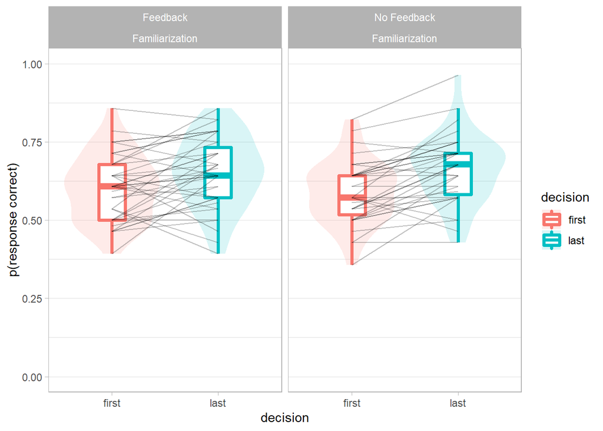

### Timing

We can look at the response time - the difference between the time the response is opened and the time the response is received.

| decision | mean | CL95.Low | CL95.High |
| --- | --- | --- | --- |
| first | 6066 | 5336 | 6795 |
| last | 1272 | 1098 | 1445 |
| Overall | 3669 | 3258 | 4079 |

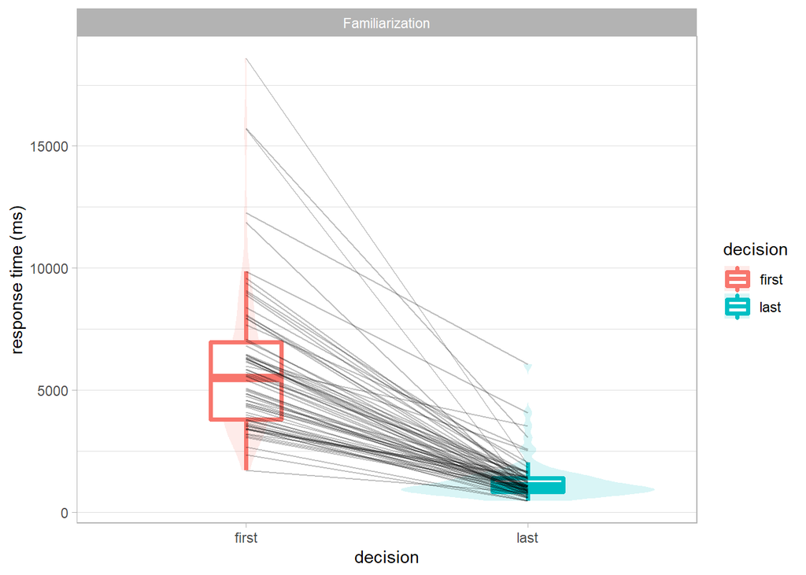

## Metacognitive performance

### Confidence

Each answer bar allowed the participant to express their confidence in that answer by selecting a higher point on the bar for a higher confidence, in a range of 0-100% for each decision.

| decision | mean | CL95.Low | CL95.High |
| --- | --- | --- | --- |
| first | 63.3 | 58.4 | 68.1 |
| last | 68.4 | 64.1 | 72.7 |
| Overall | 65.8 | 61.3 | 70.3 |

| decision | mean | CL95.Low | CL95.High | FeedbackCondition |
| --- | --- | --- | --- | --- |
| first | 66.322 | 59.500 | 73.144 | Feedback |
| last | 70.988 | 64.903 | 77.073 | Feedback |
| Overall | 68.655 | 62.310 | 75.001 | Feedback |
| first | 59.848 | 52.902 | 66.795 | No Feedback |
| last | 65.455 | 59.288 | 71.621 | No Feedback |
| Overall | 62.651 | 56.168 | 69.135 | No Feedback |

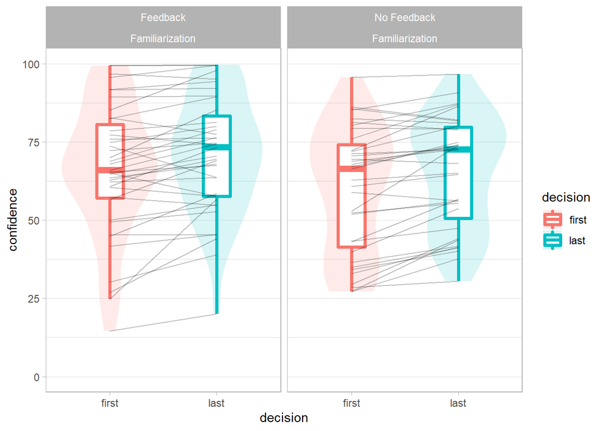

### Relationship between confidence and p(correct)

Participants indicated the confidence in their decisions simultaneously with the decisions themselves. We can thus explore how well a participant’s confidence signals their accuracy. We provide only a brief examination here where normalised responses are split into high and low confidence for each participant, and the accuracies of the two categories are compared. This is done separately for first and last decisions.

| decision | mean | CL95.Low | CL95.High |
| --- | --- | --- | --- |
| first | .051 | .004 | .098 |
| last | .095 | .050 | .140 |
| Overall | .073 | .035 | .111 |

```
## [1] "p(correct|high confidence) - p(correct|low confidence) for initial estimates"
```

```
## Bayes factor analysis
## --------------
## [1] Alt., r=0.707 : 1.112326 ±0%
##
## Against denominator:
##   Null, mu = 0
## ---
## Bayes factor type: BFoneSample, JZS
```

```
## [1] "p(correct|high confidence) - p(correct|low confidence) for final decisions"
```

```
## Bayes factor analysis
## --------------
## [1] Alt., r=0.707 : 264.8125 ±0%
##
## Against denominator:
##   Null, mu = 0
## ---
## Bayes factor type: BFoneSample, JZS
```

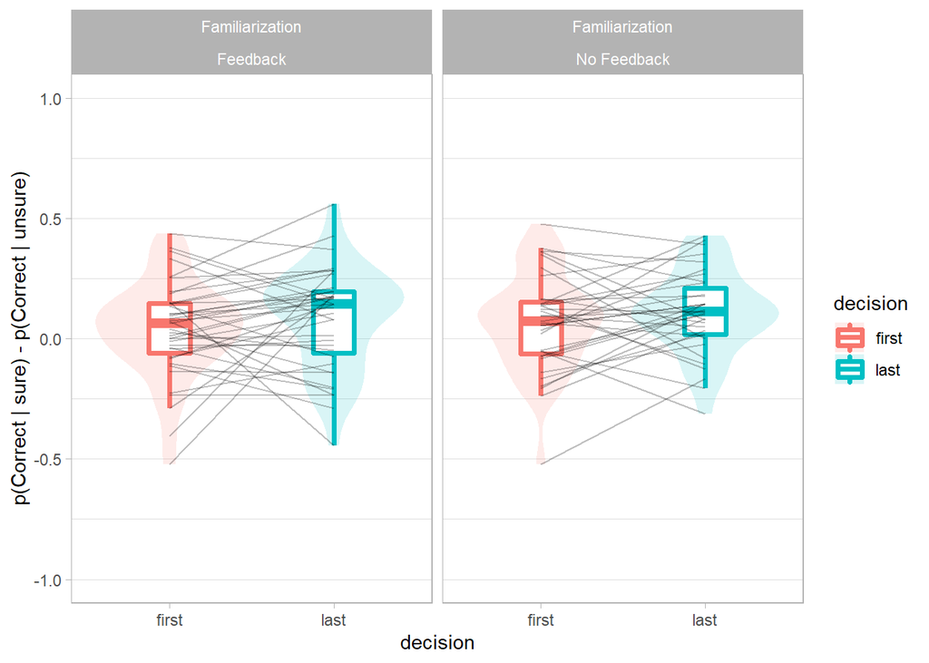

## Advisor performance

### Accuracy

| advisor0idDescription | FeedbackCondition | advisorAccuracy | advisorAgree |
| --- | --- | --- | --- |
| highAgreement | Feedback | .684 | .761 |
| highAgreement | No Feedback | .643 | .794 |
| lowAgreement | Feedback | .708 | .600 |
| lowAgreement | No Feedback | .722 | .591 |

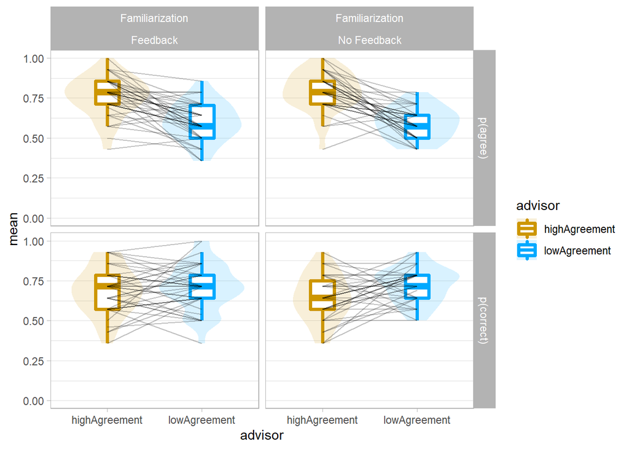

### Influence

The measure of influence is the extent to which a participant’s confidence moves in the expected direction as a function of the advice (increasing when agreed with, decreasing when disagreed with).

Influence is the primary outcome measure, and is thus expected to differ between advisors and feedback conditions.

| advisor0idDescription | FeedbackCondition | advisorInfluence |
| --- | --- | --- |
| highAgreement | Feedback | 15.4 |
| highAgreement | No Feedback | 25.4 |
| lowAgreement | Feedback | 26.5 |
| lowAgreement | No Feedback | 33.8 |

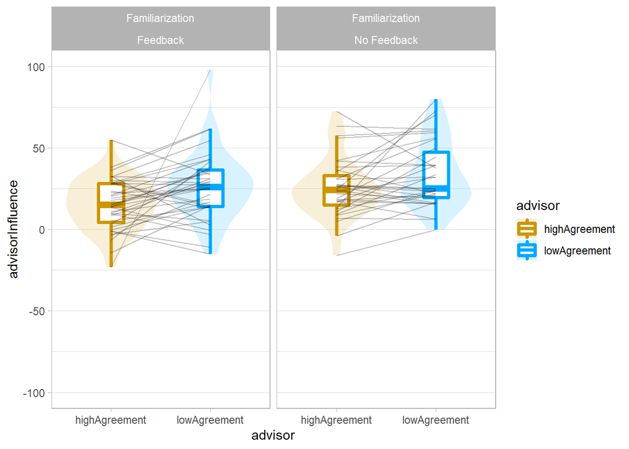

#### Influence distribution

It’s good to keep a general eye on the distribution of weight-on-advice on a trial-by-trial basis.

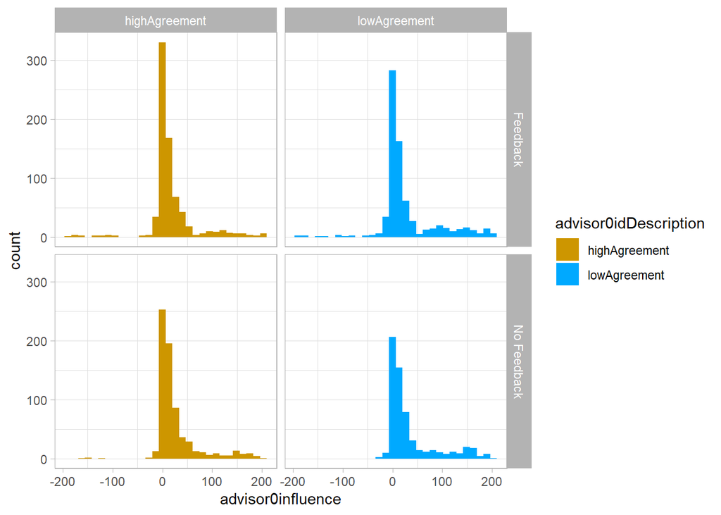

#### Is initial accuracy or initial confidence a better predictor of influence?

| property | BF | estimate | statistic | p.value | parameter | conf.low | conf.high |
| --- | --- | --- | --- | --- | --- | --- | --- |
| accuracy | 21081.43481 | -0.21385171 | -1.2986393 | 0.2671560 | 25.95946 | -0.5255066 | 0.1445297 |
| confidence | 9.88828 | -0.03871503 | -0.1898181 | 0.4344556 | 25.95946 | -0.3879231 | 0.3214165 |

## Hypothesis testing

The hypotheses being tested here are:

1. Participants will select the high agreement advisor at a rate greater than chance when given feedback.

*t*(38) = 0.46, *p* = .648, *d* = 0.07, BF = 0.19; *M* = 0.52 [0.42, 0.62], $\mu$ = 0.5

*t*(34) = 2.62, *p* = .013, *d* = 0.44, BF = 3.39; *M* = 0.63 [0.53, 0.73], $\mu$ = 0.5

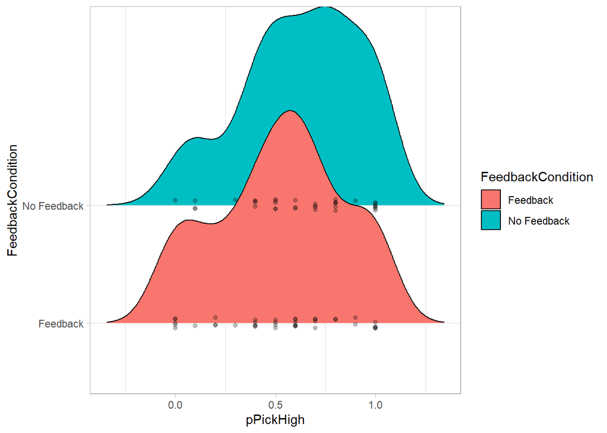

### Summary

# Conclusions

# Credits

## Acknowledgements

Thanks as always to Nick Yeung and the other folks at the [ACC Lab](https://www.psy.ox.ac.uk/research/attention-cognitive-control-lab).

## R Packages

[output not shown]

## Funding

Matt Jaquiery is funded by a studentship from the [Medical Research Council](https://mrc.ukri.org/) (reference 1943590) and the University of Oxford [Department of Experimental Psychology](https://www.psy.ox.ac.uk/) (reference 17/18_MSD_661552).